## Customer Life-Time Value

```r
options(scipen = 99)
set.seed(2)

# Loading all required packages
library(ggplot2)
library(plyr)
library(glmnet)
library(caret)
library(pROC)
library(randomForest)
library(gbm)
library(lubridate)
library(factoextra)
library(cluster)
```

## Exploratory Data Analysis:

```r
# Reading the csv data
data.ltv =read.csv("ltv.csv")

# Data structure
str(data.ltv)
```

```
## 'data.frame':    403835 obs. of  9 variables:
##  $ id       : int  1 1 1 1 1 1 2 2 2 2 ...
##  $ status   : int  0 1 1 1 1 2 0 1 1 1 ...
##  $ gender   : Factor w/ 2 levels "F","M": 2 2 2 2 2 2 1 1 1 1 ...
##  $ date     : Factor w/ 1461 levels "2011-01-01","2011-01-02",..: 1400 1401 1402 1445 1449 1453 981 982 983 985 ...
##  $ pages    : int  7 6 6 1 1 0 7 9 7 8 ...
##  $ onsite   : int  3 8 20 1 1 0 23 30 19 3 ...
##  $ entered  : int  1 0 1 0 0 0 1 1 1 1 ...
##  $ completed: int  1 0 0 0 0 0 1 1 1 0 ...
##  $ holiday  : int  0 0 0 0 0 0 0 0 0 0 ...
```

```r
summary(data.ltv)
```

```
##        id            status       gender             date
##  Min.   :    1   Min.   :0.0000   F:358716   2013-12-24:  1132
##  1st Qu.: 2537   1st Qu.:1.0000   M: 45119   2012-12-24:   954
##  Median : 5025   Median :1.0000              2013-12-17:   821
##  Mean   : 5017   Mean   :0.9909              2013-12-18:   808
##  3rd Qu.: 7495   3rd Qu.:1.0000              2013-10-27:   801
##  Max.   :10000   Max.   :2.0000              2013-12-23:   789
##                                              (Other)   :398530
##      pages            onsite           entered         completed
##  Min.   : 0.000   Min.   :  0.000   Min.   :0.0000   Min.   :0.0000
##  1st Qu.: 3.000   1st Qu.:  2.000   1st Qu.:1.0000   1st Qu.:0.0000
##  Median : 5.000   Median :  5.000   Median :1.0000   Median :1.0000
##  Mean   : 5.018   Mean   :  8.831   Mean   :0.7821   Mean   :0.5627
##  3rd Qu.: 7.000   3rd Qu.: 11.000   3rd Qu.:1.0000   3rd Qu.:1.0000
##  Max.   :10.000   Max.   :220.000   Max.   :1.0000   Max.   :1.0000
##
##     holiday
##  Min.   :0.0000
##  1st Qu.:0.0000
##  Median :0.0000
##  Mean   :0.2277
##  3rd Qu.:0.0000
##  Max.   :1.0000
##
```

After initial exploration of the data in Excel, we conculded the following:

1. No missing values(NA) present in the data
2. No discrepancy in the collection of observations
3. Number of females are way more than males

Data requires no further cleaning.

```r
#Sort data according to id and then status
sorted.data = data.ltv[with(data.ltv, order(id, status)), ]

#Find all records who indicate new ids
x = sorted.data[sorted.data$status==0,]

#Find number of records who are open
y = sorted.data[sorted.data$status==1,]

#Unique ids who were open
uniq = unique(y$id)

#Non open ids (A-B) set difference
sorted.data.1 = subset(sorted.data, !(id %in% uniq))

#Find number of records who left
z = sorted.data[sorted.data$status==2,]

# All ids who did not leave
c = sorted.data[sorted.data$completed==1,]
```

## Males vs Female Count in the dataset

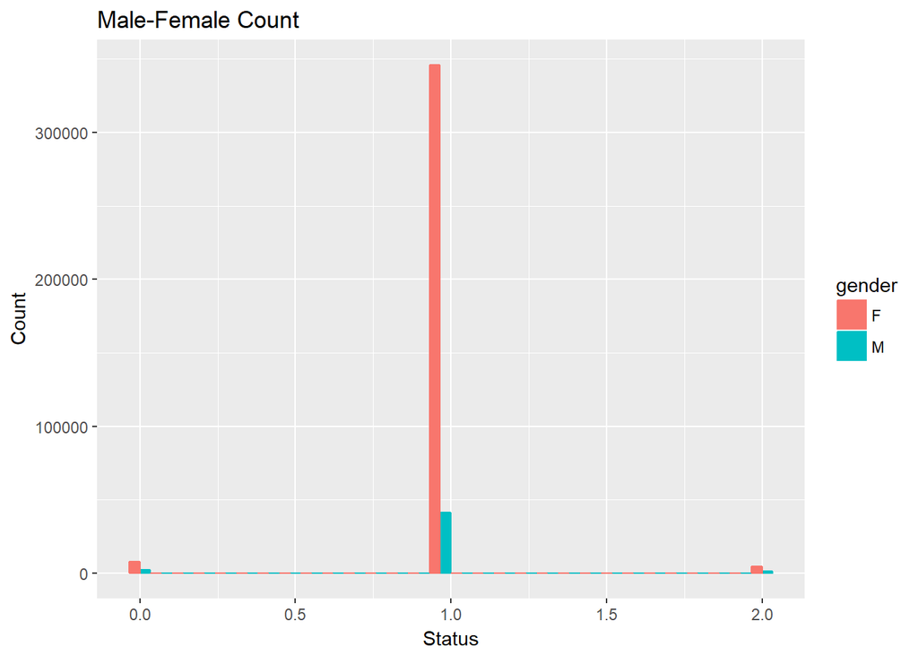

```r
# Plot to showcase distribution of males and females in the dataset
ggplot(data = sorted.data, mapping = aes(x=status, color=gender, fill = gender)) + geom_histogram(position = 'dodge') + labs(title='Male-Female Count', x = 'Status', y = 'Count')
```

From the above plot, it appears that there are more females than males in all three status categories. In status 1, the gender difference is prominent.

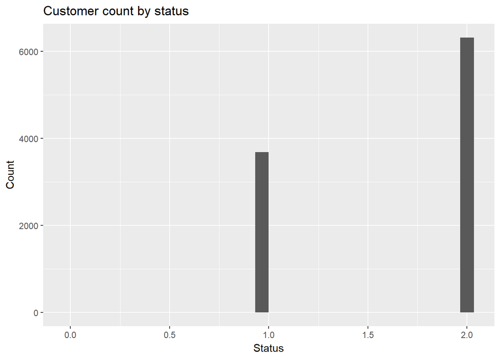

```r
# Extracting the final status of every customer
temp = sorted.data[sorted.data$id==1, ]
x = temp[nrow(temp),]
final = data.frame(matrix(ncol = 9, nrow = 0))
colnames(final)=colnames(sorted.data)
final = rbind(final,x)
for(i in 2:10000){
  temp = sorted.data[sorted.data$id==i,]
  x = temp[nrow(temp),]
  final = rbind(final,x)
}

# Plotting the count of customers based on Status
ggplot(data=final, mapping = aes(x=status)) + geom_histogram() + labs(title = 'Customer count by status', x = 'Status', y ='Count')
```

For the provided time-period in the dataset, at the end of 2014, we can observe that the number of customers ending their subscription is more than the number of customers who are still subscribed.

## Calculating leaving rate of customers grouped by gender

```r
# Separating males and females in two separate data frames
df.male = final[final$gender=="M",]
df.female = final[final$gender=="F",]

# Separation via status and calculation of leaving rate
df.male.1 = df.male[df.male$status=="1",]
df.male.2 = df.male[df.male$status=="2",]
leaving.rate.m = nrow(df.male.2)/nrow(df.male)

# Male leaving rate
leaving.rate.m
```

```
## [1] 0.7398844
```

```r
# Separation via status and calculation of leaving rate
df.female.1 = df.female[df.female$status=="1",]
df.female.2 = df.female[df.female$status=="2",]
leaving.rate.f = nrow(df.female.2)/nrow(df.female)

# Female leaving rate
leaving.rate.f
```

```
## [1] 0.6033569
```

The leaving rate for males is greater than that of females for the entire given time duration

## Completion rate calculation

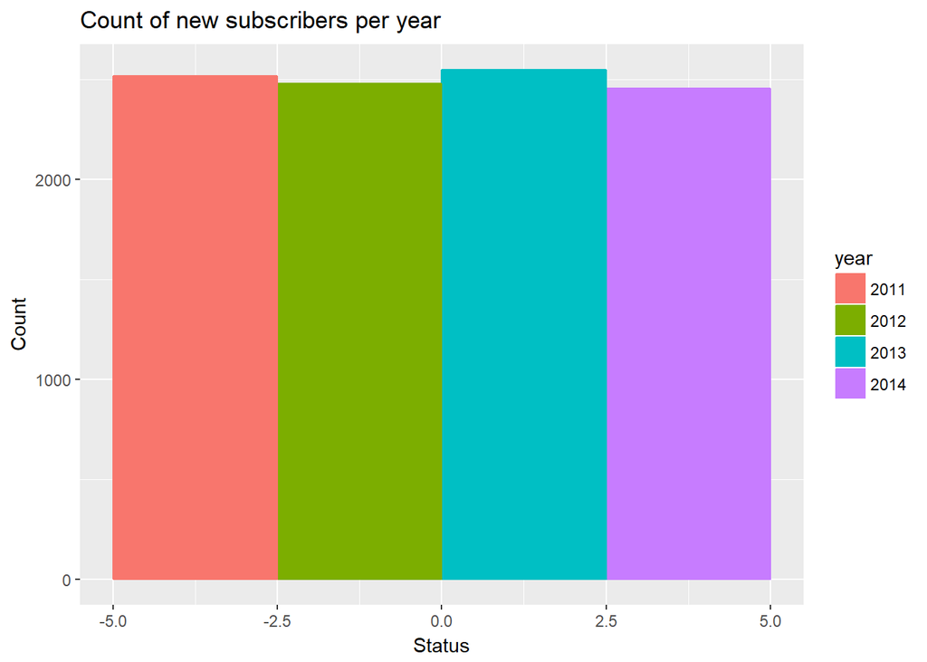

```r
# Extract year from all dates and adding to main data set
year<-as.vector(strftime(sorted.data$date, "%Y"))
augment.sorted.data = cbind(sorted.data,year)

# Histogram plots for different customer status
df.0 = augment.sorted.data[augment.sorted.data$status=="0",]
ggplot(data = df.0, mapping = aes(x = status, color = year, fill = year)) + geom_histogram(position = 'dodge', binwidth = 10) + labs(title='Count of new subscribers per year', x = 'Status', y='Count')
```

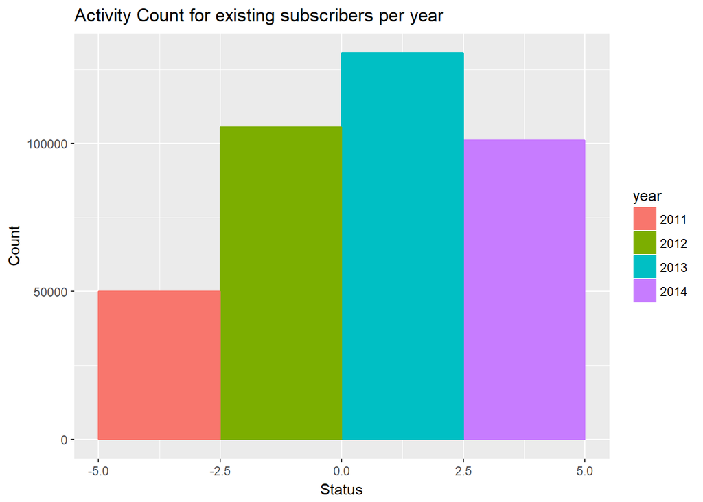

```r
df.1 = augment.sorted.data[augment.sorted.data$status=="1",]
ggplot(data = df.1, mapping = aes(x = status, color = year, fill = year)) + geom_histogram(position = 'dodge',binwidth = 10) + labs(title='Activity Count for existing subscribers per year', x = 'Status', y='Count')
```

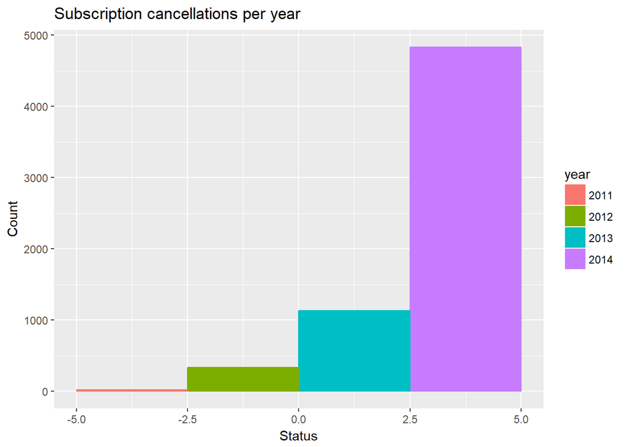

```r
df.2 = augment.sorted.data[augment.sorted.data$status=="2",]
ggplot(data = df.2, mapping = aes(x = status, color = year, fill = year)) + geom_histogram(position = 'dodge',binwidth = 10) + labs(title='Subscription cancellations per year', x = 'Status', y='Count')
```

```r
# Completion rate determination
completed.1 = df.1[df.1$completed=="1",]
completion.rate.1 =  nrow(completed.1)/nrow(df.1)
completion.rate.all =  nrow(completed.1)/nrow(sorted.data)

completion.rate.all
```

```
## [1] 0.537987
```

## Completed Orders Analysis

```r
cmpltd.1 = subset(completed.1, select = c(id,completed))
sum.completed.1=data.frame(table(cmpltd.1$id))

# completed order per customer who unsubscribed
z = sorted.data[sorted.data$status==2,]
z = subset(z, select = c(id,completed))
count.completed.2 = data.frame(table(z$id))
df.2.completed = merge(sum.completed.1,count.completed.2, by = "Var1")
df.2.completed = df.2.completed[with(df.2.completed, order(Var1)), ]
head(df.2.completed, 5)
```

```
##      Var1 Freq.x Freq.y
## 700     2     13      1
## 2818    5     12      1
## 4946    8      6      1
## 5628    9     69      1
## 207    13     35      1
```

```r
# Completed order per customer who have not unsubscribed
z2 = subset(sorted.data, !(id %in% z$id))
z2 = subset(z2, select = c(id,completed))
count.completed.1 = data.frame(table(z2$id))
df.1.completed = merge(sum.completed.1,count.completed.1, by = "Var1")
df.1.completed = df.1.completed[with(df.1.completed, order(Var1)), ]
head(df.1.completed, 5)
```

```
##      Var1 Freq.x Freq.y
## 796     3     16     29
## 1225    4     15     24
## 2006    6      6      7
## 2405    7     12     23
## 1      10     11     16
```

## Feature Engineering

```r
# function to generate new features and aggregate over different time periods
data.generator = function(partitionDate, endDate){
data.ltv.new = read.csv("ltv.csv")
data.ltv.new$date = as.Date(data.ltv.new$date)

##Customers who are still subscribed in 2013
data.ltv.1 = subset(data.ltv.new, subset = data.ltv.new$date<= as.Date(partitionDate))
data.ltv.2 = data.ltv.1[data.ltv.1$status==2,]

left.id = unique(data.ltv.2$id)

data.ltv.2014 = data.ltv.1[!data.ltv.1$id %in% left.id,]

##New features:
data.pages = subset(data.ltv.2014, select = c(id,pages,onsite,entered,completed))
sum.data.pages=data.frame(table(data.ltv.2014$id))

## aggregating total pages, onsite, entered, completed, holiday orders
data.ltv.aggregate = aggregate(. ~id, data=data.ltv.2014, sum)

#select relevant features
data.ltv.aggregate = subset(data.ltv.aggregate, select = c('id','pages','onsite','entered','completed','holiday'))

completed_sum = sum(data.ltv.aggregate$completed)

#calculate new features
data.ltv.features = mutate(data.ltv.aggregate, pm= pages/onsite, rate.completed = completed/entered, holiday_complete = holiday/completed, complete_onsite = completed/onsite, my_complete = completed/completed_sum)

#get a coaggulated data frame
data.final = merge(data.ltv.new, data.ltv.features, by = "id")

#sort
sorted.data.final = data.final[with(data.final, order(id, status)), ]

# get unique id from data set 2014 (did not leave)
data.final.agg = data.frame(matrix(ncol = 19, nrow = 0))
colnames(data.final.agg)=colnames(sorted.data.final)
unqi = unique(data.ltv.2014$id)

#for all ids get the joining dates
for(i in unqi){
  temp = sorted.data.final[sorted.data.final$id==i,]
  x = temp[1,]
  data.final.agg = rbind(data.final.agg,x)
}

data.ltv.2014.all2 = subset(data.ltv.new, subset = (data.ltv.new$date <= as.Date(endDate)))
data.ltv.2014.test = data.ltv.2014.all2[data.ltv.2014.all2$id %in% unqi,]

sorted.data.test = data.ltv.2014.test[with(data.ltv.2014.test, order(id, status)), ]

# get unique id from data set 2014 (did not leave)
data.final.agg.test = data.frame(matrix(ncol = 19, nrow = 0))
colnames(data.final.agg.test)=colnames(sorted.data.test)

unqi2 = unique(sorted.data.test$id)

for(i in unqi2){
  temp = sorted.data.test[sorted.data.test$id==i,]
  x = temp[nrow(temp),]
  data.final.agg.test = rbind(data.final.agg.test,x)
}

##############################################################

#FINAL DATA MODEL
data.model = cbind(data.final.agg, finalDate = data.final.agg.test$date, finalStatus =data.final.agg.test$status)
return(data.model)
}
```

## Attrition Model:

Predict whether a customer will cancel their subscription in the near future

## Partition and Aggregation of Data over different time periods

```r
# partition by dates and binding with 'data.final.model'
data.final.model = data.frame(matrix(ncol = 21, nrow = 0))
data.current = data.generator('2011-06-30','2011-12-31')
colnames(data.final.model)=colnames(data.current)

data.final.model = rbind(data.final.model,data.current)

data.current = data.generator('2012-01-01','2012-06-30')
data.final.model = rbind(data.final.model,data.current)

data.current = data.generator('2012-07-01','2012-12-31')
data.final.model = rbind(data.final.model,data.current)

data.current = data.generator('2013-01-01','2013-06-30')
data.final.model = rbind(data.final.model,data.current)

data.current = data.generator('2013-07-01','2013-12-31')
data.final.model = rbind(data.final.model,data.current)

data.current = data.generator('2014-01-01','2014-06-30')
data.final.model = rbind(data.final.model,data.current)

data.current = data.generator('2014-07-01','2014-12-31')
data.final.model = rbind(data.final.model,data.current)

data.model = data.final.model
```

## Data splitting for training and testing the model

```r
# get the unique ids
uniqueID = unique(data.model$id)

data.model$finalStatus = as.factor(data.model$finalStatus)

# Assigning 20% data for testing and 80% data for training
test = sample(length(uniqueID), size=0.2*length(uniqueID))

test.data = data.model[data.model$id %in% test,]
train.data = data.model[!data.model$id %in% test,]

train.finalStatus = train.data$finalStatus
train.finalDate= train.data$finalDate

test.finalStatus = test.data$finalStatus

test.data.orig = test.data
test.data = test.data[,c("id","status","gender","date","holiday.y","pm","rate.completed","finalDate","holiday_complete","complete_onsite","my_complete")]

train.data.temp = train.data[,c("id","status","gender","date","holiday.y","pm","rate.completed","finalDate","holiday_complete","complete_onsite","my_complete")]

train.data.temp$gender = as.numeric(train.data.temp$gender)
test.data$finalDate = as.numeric(test.data$finalDate)

train.output = train.data[,"finalStatus"]
test.data$date = as.numeric(test.data$date)

test.data$finalDate = as.numeric(test.data$finalDate)

# Converting data types to appropriate format for model fitting
train.data.temp$date = as.numeric(train.data.temp$date)
train.data.temp$finalDate = as.numeric(train.data.temp$finalDate)
test.data$gender = as.numeric(test.data$gender)
```

## 10-Fold Cross Validation

```r
# Preparing data for 10-fold Cross-Validation
unique_id = unique(train.data.temp$id)

seq = seq(1:length(unique_id))

seq = sample(seq)
df = as.data.frame(seq)

# creating data folds
folds <- cut(df$seq, breaks = 10, labels = FALSE)
df = as.data.frame(cbind(id = unique_id, folds))

train.data.temp_folds = train.data.temp
train.data.temp_folds = dplyr::inner_join(train.data.temp, df, by = "id")

fold = train.data.temp_folds$folds
```

## Fitting Cross-Validated Regularized Logisitic Regression

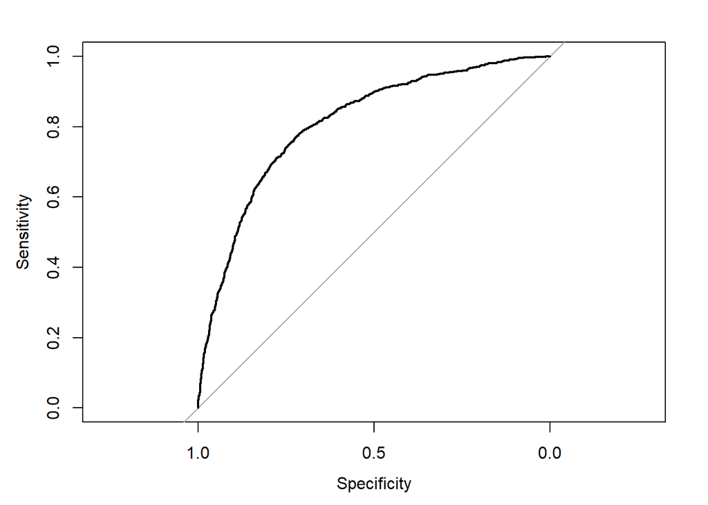

```r
glm.result =cv.glmnet(as.matrix(train.data.temp),train.output, family = "binomial", alpha =1, foldid = fold, nfolds=10)

# Choosing the minimum CV error lambda value
bestlam = glm.result$lambda.min

# Making predictions using the fitted model
lasso.pred = predict(glm.result, type = 'response', s=bestlam, newx = as.matrix(test.data))
lasso.class = rep(1,nrow(lasso.pred))
lasso.class[lasso.pred>0.25] = 2

# Checking model performance on test data
myROC = roc(predictor=as.numeric(lasso.pred), response = test.finalStatus, positive = levels(test.finalStatus)[2])
plot(myROC)
```

```r
confusionMatrix(data = lasso.class, test.finalStatus, positive = levels(test.finalStatus)[2])
```

```
## Confusion Matrix and Statistics
##
##           Reference
## Prediction    1    2
##          1 3299  324
##          2  855  717
##
##                Accuracy : 0.7731
##                  95% CI : (0.7614, 0.7844)
##     No Information Rate : 0.7996
##     P-Value [Acc > NIR] : 1
##
##                   Kappa : 0.4054
##  Mcnemar's Test P-Value : <0.0000000000000002
##
##             Sensitivity : 0.6888
##             Specificity : 0.7942
##          Pos Pred Value : 0.4561
##          Neg Pred Value : 0.9106
##              Prevalence : 0.2004
##          Detection Rate : 0.1380
##    Detection Prevalence : 0.3026
##       Balanced Accuracy : 0.7415
##
##        'Positive' Class : 2
##
```

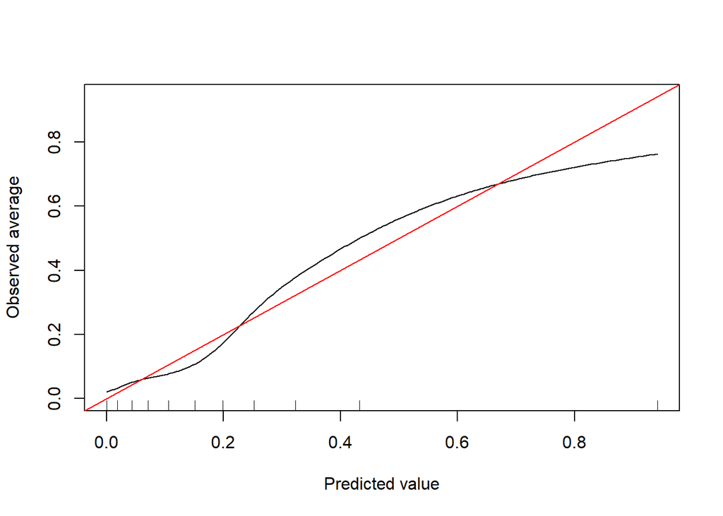

```r
#Calibration Plot
calibrate.plot(test.finalStatus, lasso.pred, shade.col = NA)
```

The confusion matrix gives Senstitvity around 69% @ specificity = 79%

Sensitivity is important for our model as False Negatives are costlier than False Positives to the e-card company.

Consider the following scenario: If we predict a customer would not leave, but he/she actually leaves, it would be a revenue loss for the company. Specificity is not of prime importance here as a customer staying in subscription despite our prediction that he/she would leave would not cause a loss for the company. In fact, it would be an additional revenue.

A 69% Sensitivity is not desirable and it indicates that the model could be improved and better results could be obtained using a better model.

The observed calibration plot indicates that the model performance is decent but is overestimating for observed probablities of around 0.7. ## Random Forest Classification Model

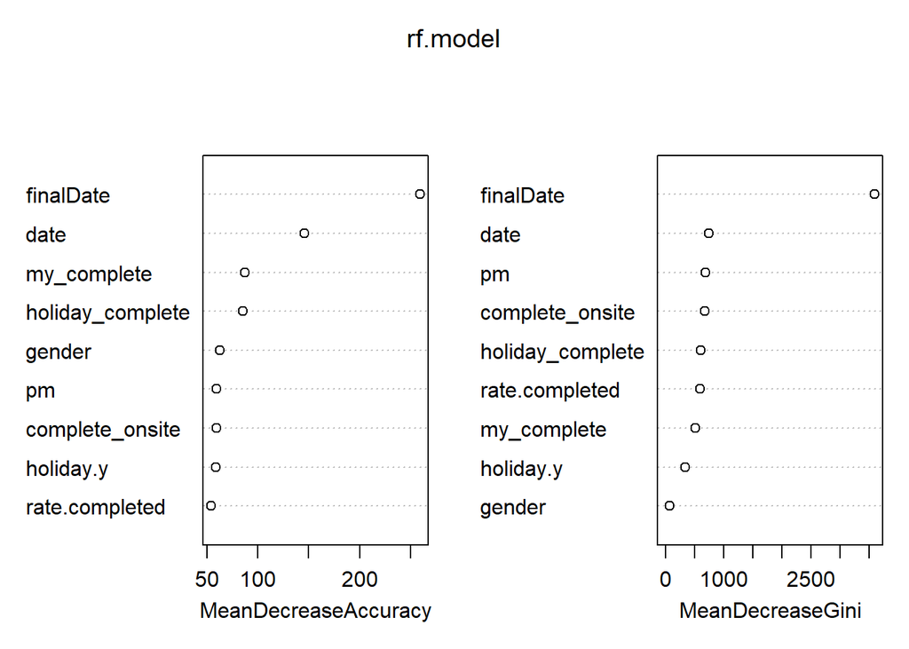

```r
# Preparing training and testing data for fitting and validating Random Forest model
train.data.temp1 = train.data[,c("id","status","gender","date","holiday.y","pm","rate.completed","holiday_complete","complete_onsite","my_complete","finalDate","finalStatus")]

test.data1 = test.data.orig[,c("id","status","gender","date","holiday.y","pm","rate.completed","holiday_complete","complete_onsite","my_complete","finalDate","finalStatus")]

# Fitting a stratified Random Forest Model on the data in order to ensure the bootstrap data has consistent customer IDs across the training data. Cut-off probability of 0.25 specified for classification in order to acheive the goal of high sensitivity
rf.model <- randomForest(finalStatus ~ gender+date+holiday.y+pm+rate.completed+finalDate+holiday_complete+complete_onsite+my_complete, data=train.data,  mtry=9, importance=TRUE, cutoff = c(0.75,0.25), strata = "id")

# Plotting Variable importance plot to see which variable has highest importance in determining the classification
varImpPlot(rf.model)
```

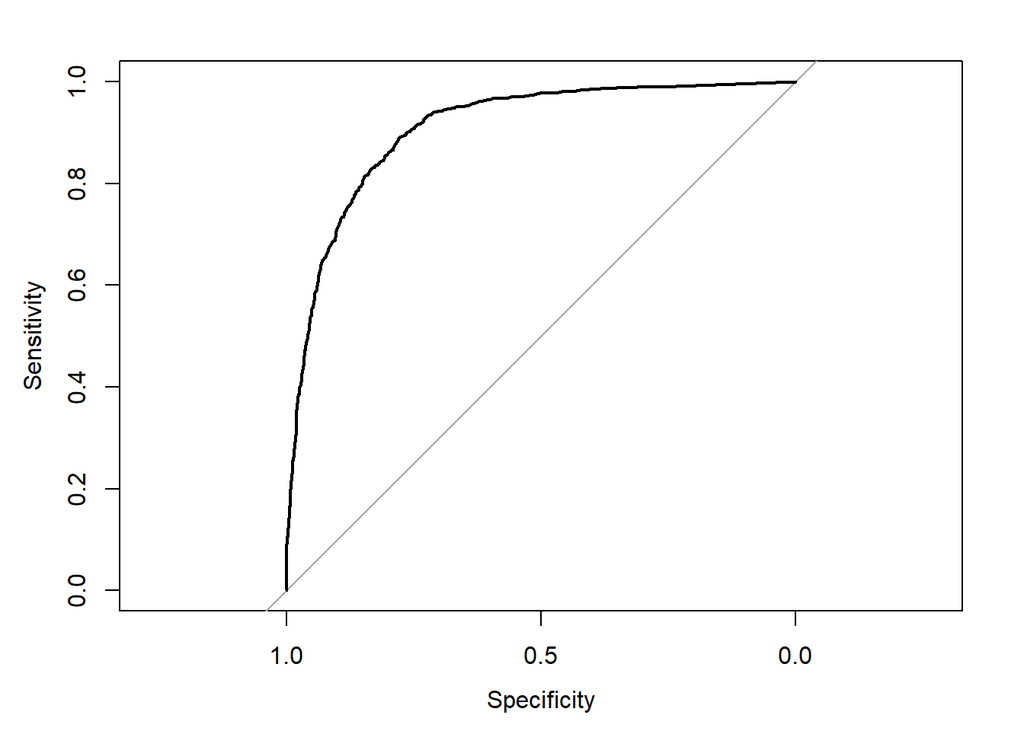

```r
# For determining the Misclassification rate by prediction using the fitted model
rf.pred1 = predict(rf.model,newdata=test.data1, type = "prob")
rf.pred = predict(rf.model,newdata=test.data1)

# Plotting ROC curve
myROC = roc(predictor=as.numeric(rf.pred1[,2]), response = test.data1$finalStatus, positive = levels(test.data1$finalStatus)[2])
plot(myROC)
```

```r
# Confusion matrix
confusionMatrix(data = rf.pred, test.data1$finalStatus, positive = levels(test.data1$finalStatus)[2])
```

```
## Confusion Matrix and Statistics
##
##           Reference
## Prediction    1    2
##          1 3385  164
##          2  769  877
##
##                Accuracy : 0.8204
##                  95% CI : (0.8097, 0.8308)
##     No Information Rate : 0.7996
##     P-Value [Acc > NIR] : 0.00008065
##
##                   Kappa : 0.5398
##  Mcnemar's Test P-Value : < 0.00000000000000022
##
##             Sensitivity : 0.8425
##             Specificity : 0.8149
##          Pos Pred Value : 0.5328
##          Neg Pred Value : 0.9538
##              Prevalence : 0.2004
##          Detection Rate : 0.1688
##    Detection Prevalence : 0.3168
##       Balanced Accuracy : 0.8287
##
##        'Positive' Class : 2
##
```

Random Forest has performed much better than the previous model, giving a sensitivity around 84%.

We shall look into another model for improvement: Gradient Boosting.

## Gradient Boosting

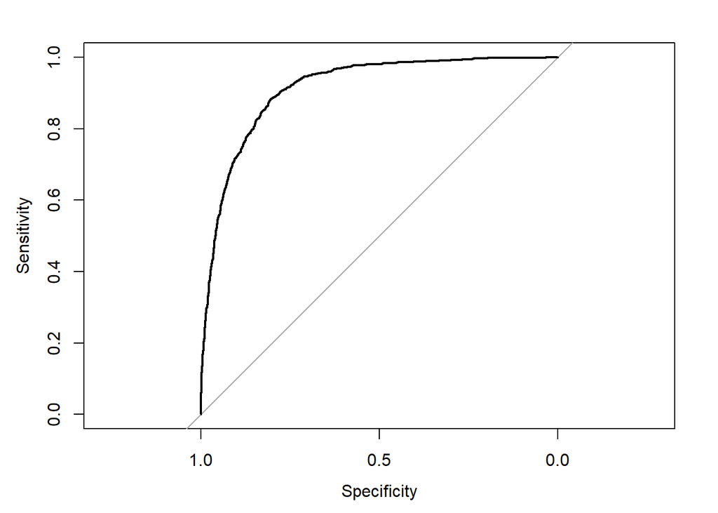

```r
# Preparing training and testing data for fitting and validating Gradient Boosted model
train.data.temp1 = train.data[,c("id","status","gender","date","holiday.y","pm","rate.completed","holiday_complete","complete_onsite","my_complete","finalDate","finalStatus")]

test.data1 = test.data.orig[,c("id","status","gender","date","holiday.y","pm","rate.completed","holiday_complete","complete_onsite","my_complete","finalDate","finalStatus")]
# Creating the train and test data for fitting the model
train.data.temp1$date = as.numeric(train.data.temp1$date)
train.data.temp1$finalDate = as.numeric(train.data.temp1$finalDate)
train.data.temp1$finalStatus = as.numeric(train.data.temp1$finalStatus)

# Converting to Bernoulli's distribution
train.data.temp1$finalStatus[train.data.temp1$finalStatus==1] = 0
train.data.temp1$finalStatus[train.data.temp1$finalStatus==2] = 1

test.data1$finalStatus = as.numeric(test.data1$finalStatus)
test.data1$finalStatus[test.data1$finalStatus==1] = 0
test.data1$finalStatus[test.data1$finalStatus==2] = 1

# Fitting a Gradient Boosting model
GBM_model = gbm(formula = finalStatus ~ gender+date+holiday.y+pm+rate.completed+finalDate+holiday_complete+complete_onsite+my_complete,
                    distribution = "bernoulli",
                    data = train.data.temp1,
                    n.trees = 2000,
                    shrinkage = 0.1,
                    n.minobsinnode = 10,
                    interaction.depth = 2)

# Prediction on test data using the GBM model
prediction <- predict(GBM_model, newdata = test.data1, type="response",n.trees=2000)

# Storing the predictions on test data
outputDataSet = data.frame("RowID" = test.data$id,
                           "ProbabilityOfResponse" = prediction)

# Setting the status using the probaility cutoff 0.2
outputDataSet$status = 0
outputDataSet$status[outputDataSet$ProbabilityOfResponse>=0.2] = 2
outputDataSet$status[outputDataSet$ProbabilityOfResponse<0.2] = 1

# Converting to original status from Bernoulli format
test.data1$finalStatus[test.data1$finalStatus==1] = 2
test.data1$finalStatus[test.data1$finalStatus==0] = 1

# Plotting tHE ROC curve
myROC = roc(predictor=outputDataSet$ProbabilityOfResponse, response = test.data1$finalStatus, positive = levels(as.factor(test.data1$finalStatus))[2])
plot(myROC)
```

```r
# Confusion matrix
confusionMatrix(data = outputDataSet$status, test.data1$finalStatus, positive = levels(as.factor(test.data1$finalStatus))[2])
```

```
## Confusion Matrix and Statistics
##
##           Reference
## Prediction    1    2
##          1 3421  154
##          2  733  887
##
##                Accuracy : 0.8293
##                  95% CI : (0.8187, 0.8394)
##     No Information Rate : 0.7996
##     P-Value [Acc > NIR] : 0.00000002942
##
##                   Kappa : 0.5591
##  Mcnemar's Test P-Value : < 0.00000000000000022
##
##             Sensitivity : 0.8521
##             Specificity : 0.8235
##          Pos Pred Value : 0.5475
##          Neg Pred Value : 0.9569
##              Prevalence : 0.2004
##          Detection Rate : 0.1707
##    Detection Prevalence : 0.3118
##       Balanced Accuracy : 0.8378
##
##        'Positive' Class : 2
##
```

## Predicting Customer Life-Time Value:

Determining the ltv of a customer in terms of revenue earned for monthly subscription cost of $1

## Getting training and testig data

```r
# Calculating difference in days between the initial date and final date for every observation status
data.model$date.diff = data.model$finalDate - data.model$date

# value in dollars at the rate of $1 per month
data.model$date.diff = data.model$date.diff/(365/12)
data.model$date.diff = as.numeric(round(data.model$date.diff, digits = 3))

# selecting unique ideas
uniqueID = unique(data.model$id)

#splitting data for training the model and testing the model using 80-20 rule
test = sample(length(uniqueID), size=0.2*length(uniqueID))
test.data = data.model[data.model$id %in% test,]
train.data = data.model[!data.model$id %in% test,]

# store the customer value(dollars) for train data
train.diff = train.data$date.diff

# store the customer value(dollars) for test data
test.diff = test.data$date.diff

test.data.orig = test.data

test.data = test.data[,c("id","status","gender","date","holiday.y","pm","rate.completed","finalDate","holiday_complete","complete_onsite","my_complete","finalStatus")]

train.data.temp = train.data[,c("id","status","gender","date","holiday.y","pm","rate.completed","finalDate","holiday_complete","complete_onsite","my_complete","finalStatus")]

# appropriate data conversions
train.data.temp$gender = as.numeric(train.data.temp$gender)
test.data$finalDate = as.numeric(test.data$finalDate)
test.data$date = as.numeric(test.data$date)
test.data$finalDate = as.numeric(test.data$finalDate)
test.data$finalStatus = as.numeric(test.data$finalStatus)
train.data.temp$date = as.numeric(train.data.temp$date)
train.data.temp$finalDate = as.numeric(train.data.temp$finalDate)
test.data$gender = as.numeric(test.data$gender)
train.data.temp$finalStatus = as.numeric(train.data.temp$finalStatus)

unique_id = unique(train.data.temp$id)

seq = seq(1:length(unique_id))

seq = sample(seq)
df = as.data.frame(seq)
```

# 10-Fold Cross Validation for Regularized logistic regression

```r
# Setting the folds
folds <- cut(df$seq, breaks = 10, labels = FALSE)
df = as.data.frame(cbind(id = unique_id, folds))

train.data.temp_folds = train.data.temp
train.data.temp_folds = dplyr::inner_join(train.data.temp, df, by = "id")

fold = train.data.temp_folds$folds

# Fitting the Regularized logistic regression model
glm.result =cv.glmnet(as.matrix(train.data.temp),train.diff, alpha = 1, foldid = fold, nfolds=10)

# choosing the lambda with min cv error
bestlam = glm.result$lambda.min

best.index = which(glm.result$lambda==glm.result$lambda.min)
glm.result$cvm[best.index]
```

```
## [1] 0.09604
```

```r
# Prediction on test data using the fitted model
lasso.pred = predict(glm.result, s=bestlam, newx = as.matrix(test.data))

# The Average Squared Error (ASE)
mean((lasso.pred - test.diff)^2)
```

```
## [1] 0.1037152
```

# Fitting a random forest regression to predict customer life-time value

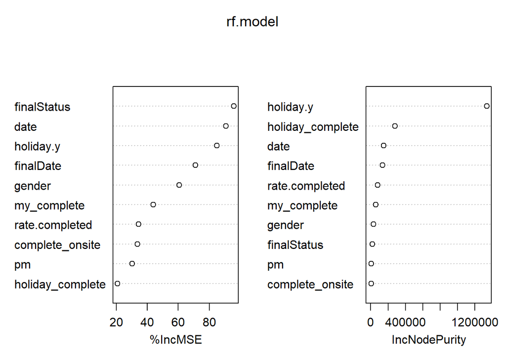

```r
# Creating the test data
test.data1 = test.data.orig[,c("id","status","gender","date","holiday.y","pm","rate.completed","holiday_complete","complete_onsite","my_complete","finalDate","finalStatus","date.diff")]

# Fitting random forest model with stratification by 'id'
rf.model <- randomForest(date.diff ~ gender+date+holiday.y+pm+rate.completed+finalDate+holiday_complete+complete_onsite+my_complete+finalStatus, data=train.data,  mtry=6, importance=TRUE, strata = "id")

# Plotting the variable importance model
varImpPlot(rf.model)
```

```r
# Prediction and determination of ASE
rf.pred = predict(rf.model, newdata=test.data1)
mean((rf.pred - test.diff)^2)
```

```
## [1] 1.621401
```

The MSE/ASE obtained from random forest is higher than that obtained from 10-Fold cross validated regularized logistic regression.

## Customer Segmentation Scheme (Including the identification of Sleeping Customers)

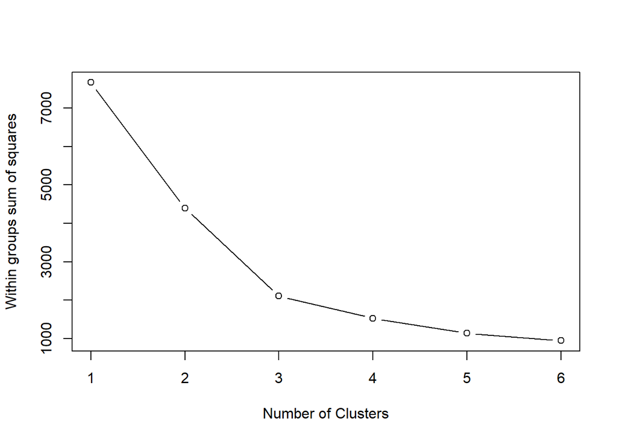

```
##       pages    onsite   entered completed data.diff
## 1 1.2580133 1.2408261 1.2630344 1.2520878 0.1177813
## 2 0.2249477 0.2027652 0.2438555 0.2132783 4.8406039
## 3 0.5576751 0.5400036 0.5253814 0.5494387 0.3687321
```

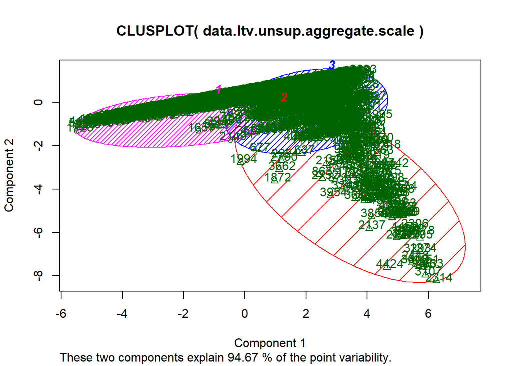

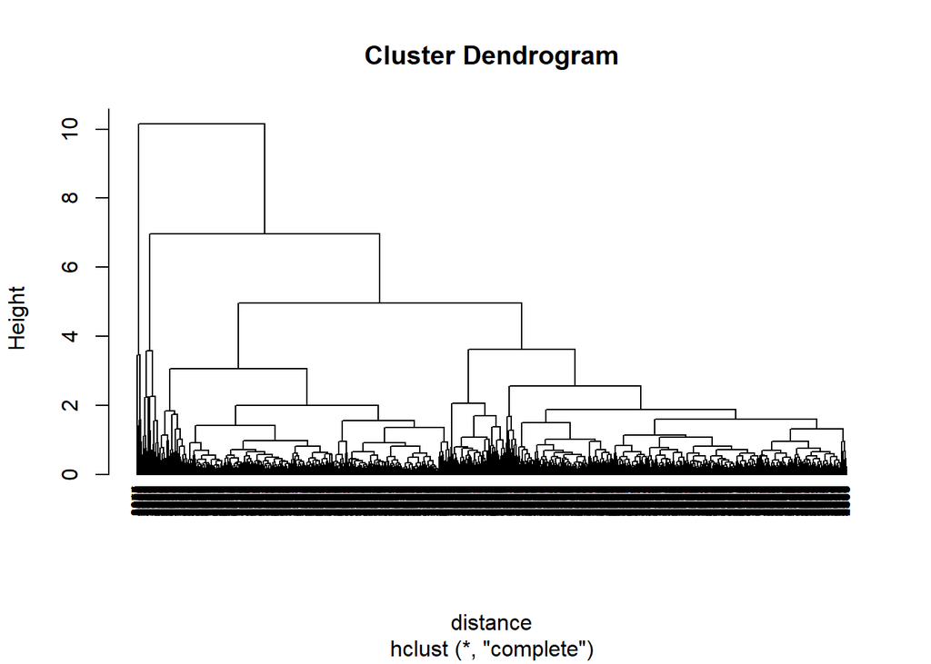

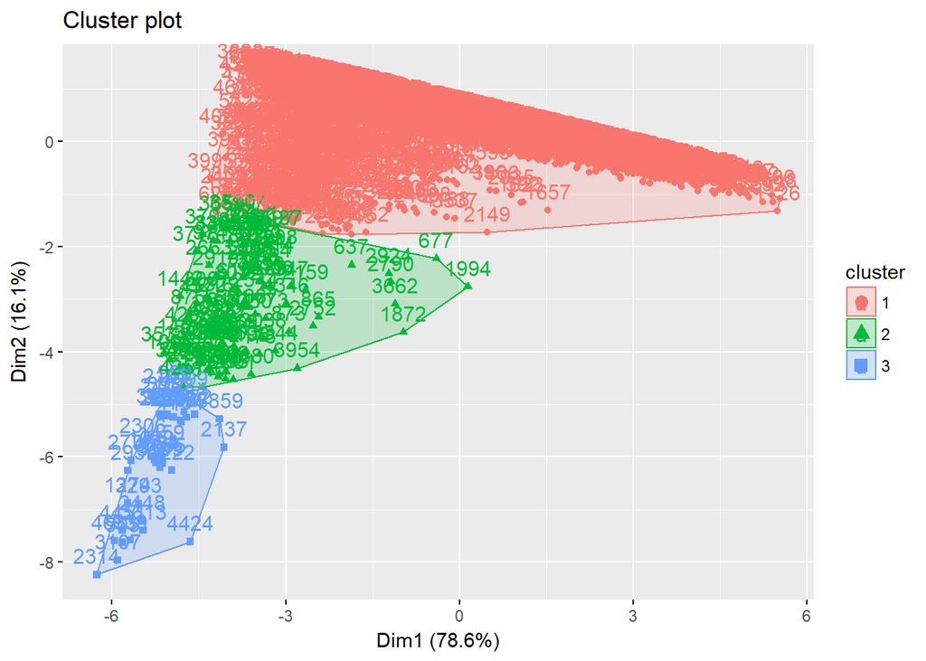

```r
# Clustering function to get a segmentation for the given start and end date
clustering = function(startDate , endDate){

# Extract the data between the entered dates in the function argument

data.ltv.new.unsup = read.csv("ltv.csv")
data.ltv.new.unsup$date = as.Date(data.ltv.new.unsup$date)
data.ltv.unsup = subset(data.ltv.new.unsup, subset = (data.ltv.new.unsup$date <= as.Date(endDate) & (data.ltv.new.unsup$date >= as.Date(startDate))))


# Data frame for people with status 2 in the given time frame
data.ltv.unsup.removed = data.ltv.unsup[data.ltv.unsup$status==2,]

# Unique ids for the people who were of status 2
left.id.unsup = unique(data.ltv.unsup.removed$id)

# Remove the ids which have status 2 from the main data frame
data.ltv.unsup.final.repeated = data.ltv.unsup[!data.ltv.unsup$id %in% left.id.unsup,]

# Unique ids present in the main data frame
present.id.unsup = unique(data.ltv.unsup.final.repeated$id)

# Columns to be dropped
drop <- c("status","gender","date","holiday")

# Remove the columns from the data
data.ltv.unsup.final.repeated.dropped = data.ltv.unsup.final.repeated[,!(names(data.ltv.unsup.final.repeated) %in% drop)]


# Aggregating the values of the features
data.ltv.unsup.aggregate = aggregate(.~id, data.ltv.unsup.final.repeated.dropped, sum)

# Empty data frame to save the date for the most recent activity for ids in the given time frame
unsup.date = data.frame(matrix(ncol = 9, nrow = 0))

# Save the maximum date in the empty data frame
for(i in present.id.unsup ){
  temp = data.ltv.unsup.final.repeated[data.ltv.unsup.final.repeated$id==i,]
  x = temp[nrow(temp),]
  unsup.date = rbind(unsup.date,x)
}

# Keeping only date and ids in a data frame
unsup.date = unsup.date[,c("id","date")]

# Final data frame with aggregated values and max date for each id
data.ltv.unsup.aggregate = merge(data.ltv.unsup.aggregate,unsup.date, by = "id")

# Saving the reference date for segmentation in the maxdate variable
maxdate = as.Date(endDate) + days(1)

# Data frame recording the in activity period of each id
data.ltv.unsup.aggregate$data.diff = maxdate - data.ltv.unsup.aggregate$date

data.ltv.unsup.aggregate = data.ltv.unsup.aggregate[,c("pages","onsite","entered","completed","data.diff")]


data.ltv.unsup.aggregate$data.diff = as.numeric(data.ltv.unsup.aggregate$data.diff)

data.ltv.unsup.aggregate.feature = data.ltv.unsup.aggregate

# Scaling the data for K-Means
data.ltv.unsup.aggregate.scale = scale(data.ltv.unsup.aggregate,FALSE)



data.ltv.unsup.aggregate.feature$class <- NULL

# Code Block to plot the elbow plot
  wssplot <- function(data, nc=15, seed=1234){
  wss <- (nrow(data)-1)*sum(apply(data,2,var))
  for (i in 2:nc){
    set.seed(seed)
    wss[i] <- sum(kmeans(data, centers=i)$withinss)}
  plot(1:nc, wss, type="b", xlab="Number of Clusters",
       ylab="Within groups sum of squares")}

wssplot(data.ltv.unsup.aggregate.scale, nc=6)

# K-means algorithm
results <- kmeans(data.ltv.unsup.aggregate.scale,3,nstart = 40)

# Summary of the k means
print(results$centers)

# Plot the observation in the graph
clusplot(data.ltv.unsup.aggregate.scale, results$cluster, color=TRUE, shade = TRUE,
    labels=2, lines=0)


# Hierarchical Clustering
distance <- dist(data.ltv.unsup.aggregate.scale,method = "euclidean")
cluster <- hclust(distance,method = 'complete')

# Plot the Dendogram Trees for Hierarchical
plot(cluster, cex = 0.6, hang = -1)

nrow(data.ltv.unsup.aggregate.scale)

# Plot the scatter plot for Heinrarchical Segmentation
grp <- cutree(cluster, k = 3)
table(grp)
fviz_cluster(list(data = data.ltv.unsup.aggregate.scale, cluster = grp),show.clust.cent = TRUE)
}

# Plotting Clusters for different time periods
clustering('2012-01-01','2012-12-31')
```

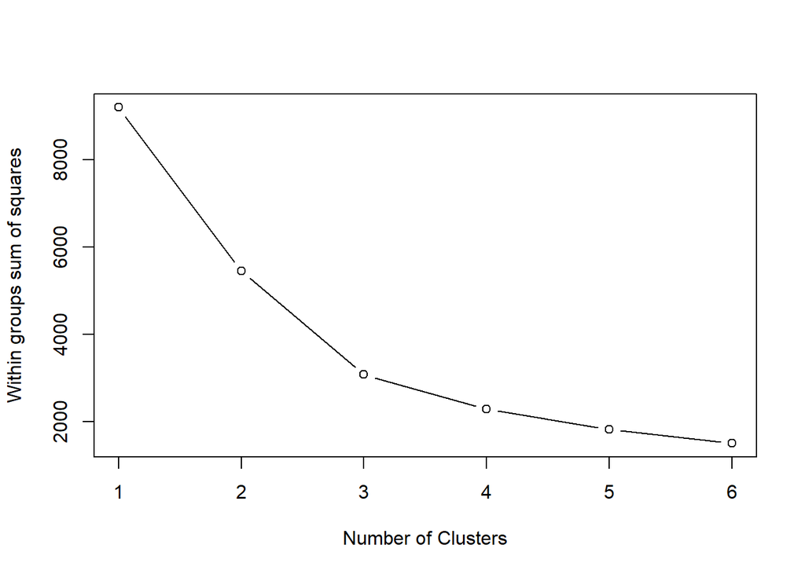

```
##       pages    onsite   entered completed data.diff
## 1 0.6253366 0.5567692 0.6175164 0.5855228 0.4119655
## 2 1.3042574 1.2895604 1.3076790 1.3057591 0.2261463
## 3 0.1734789 0.1559168 0.1758866 0.1446233 2.9114020
```

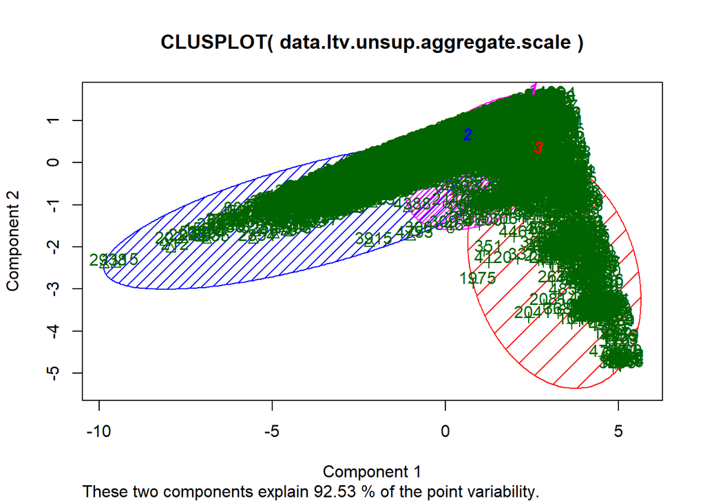

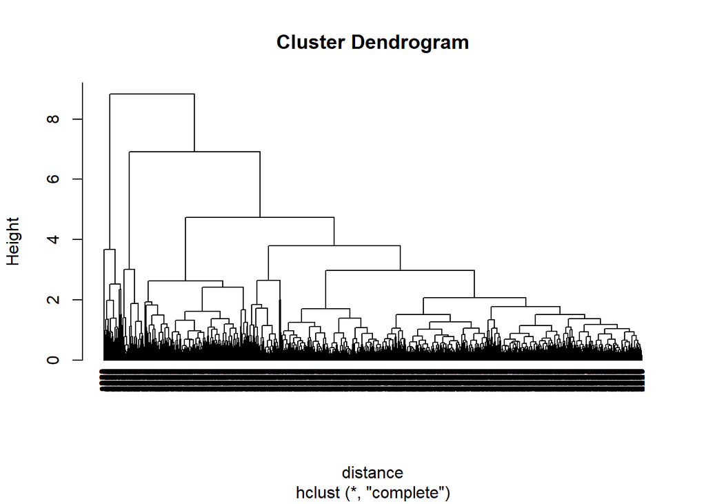

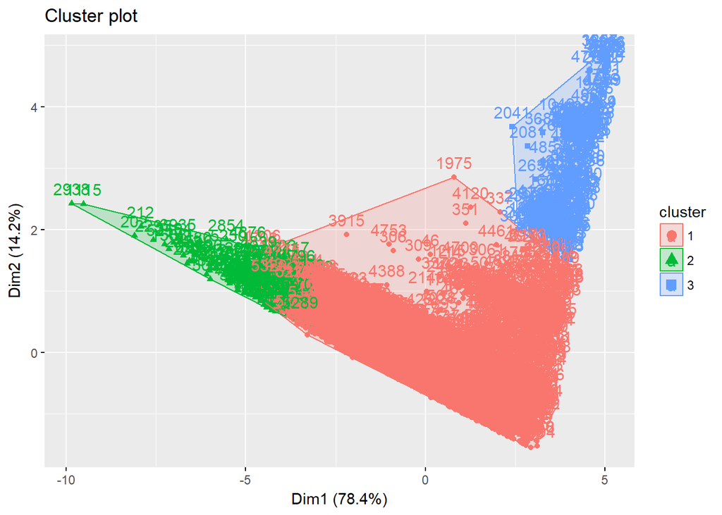

```r
clustering('2013-01-01','2013-06-30')
```

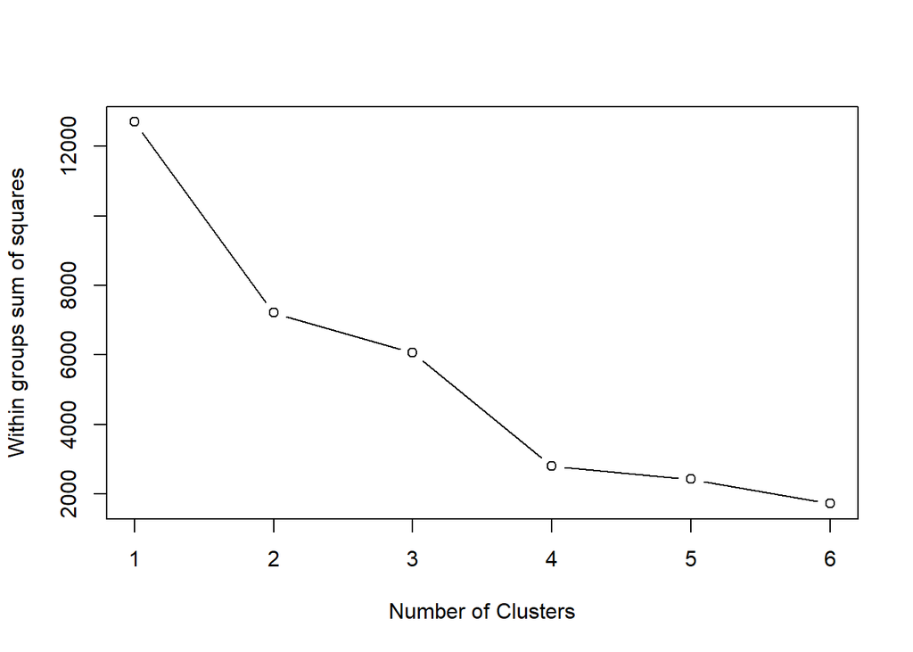

```
##       pages    onsite   entered completed data.diff
## 1 0.5785656 0.5876229 0.5567849 0.5652790 5.6332910
## 2 0.5236955 0.5271867 0.4981636 0.5253868 0.3244380
## 3 1.5558825 1.5383486 1.5687462 1.5512500 0.2737832
```

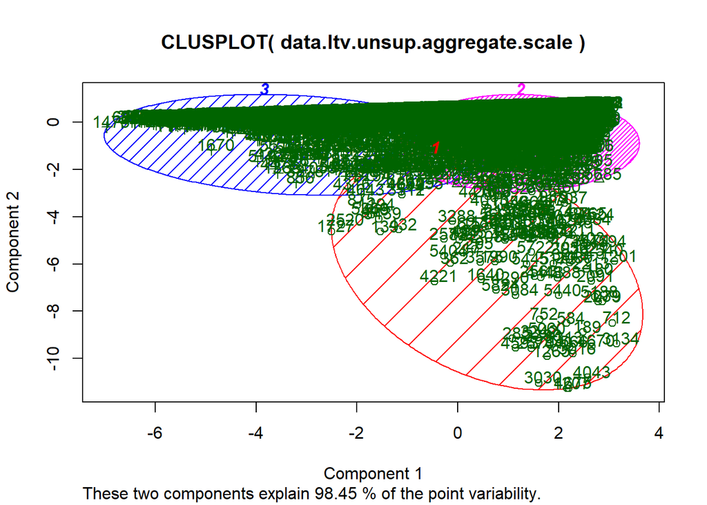

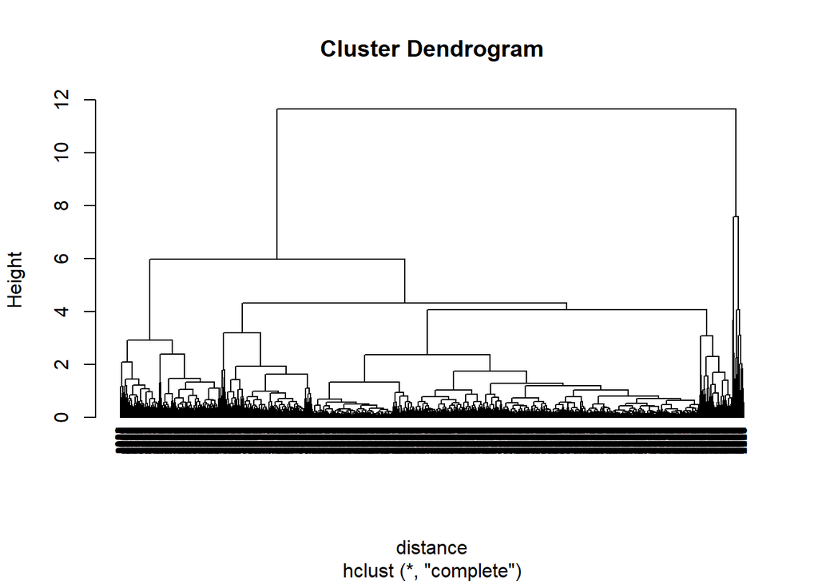

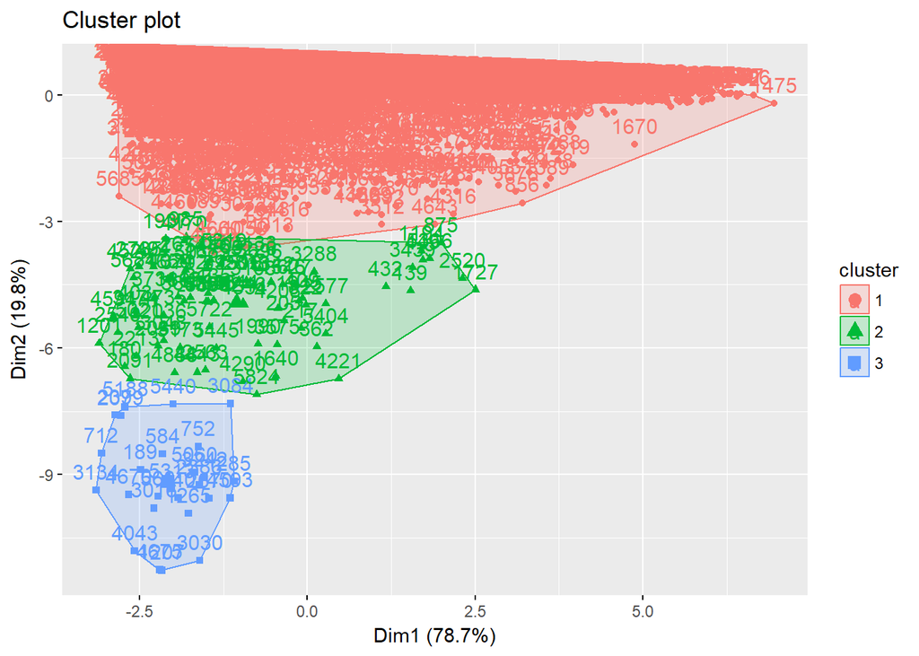

```r
clustering('2011-01-01','2014-06-30')
```

## K-Means Features used: 1) Onsite : The time spent by a particular id on the web page 2) Pages : Number of pages visited by a particular id 3) Completed : Number of completed orders 4) Entered : Flag indicating whether or not user entered the send order path (We aggregated all the above features for every id in the given time frame) 5) data.diff : The difference in the last date/reference-date and the most recent activity date in days.

We tried to segment customers based on their activities and website utilization trends with a specific focus on sleeping customers. We considered the above mentioned features where each feature will convey some message about user activity and the data.diff gives the information about the inactivity in recent past.

When we combined the inactivity time with the aggregated features we got to know the activity trends of the customer for a given time frame. Based on the combined information of all the ids we calculated the clusters and their means.

We classified the segment with the least means for the aggregated features and the highest mean for data.diff as sleeping customers cluster. While the other clusters are classified as moderately active and highly active customers.

## Hierarchical Clustering:

Features used: 1) Onsite : The time spent by a particular id on the web page 2) Pages : Number of pages visited by a particular id 3) Completed : Number of completed orders 4) Entered : Flag indicating whether or not user entered the send order path (We aggregated all the above features for every id in the given time frame) 5) data.diff : The difference in the last date/reference-date and the most recent activity date in days.

The hierarchical model starts making clusters with the minimum distance betwwen two observations and the clusters are made till all the observations are covered in one cluster. We can interpret the Dendogram Graph by cutting at a particular height and observe the clusters. We cut the tree at a height and observed that the observation with similar characterstics are clustered together and this can be seen in the cluster plot for Heirarchical Clustering.

## References

1. 95791 - Data Mining
2. R Documentation
3. www.r-statistics.com
4. www.rpubs.com
5. ISL Textbook